# PhantomPurgeR: Novaseq Lane 1 Dataset Analysis Vignette

Rick Farouni

2020-01-15

```r
library(PhantomPurgeR)
```

### Read filepaths of all h5 files found in the data input folder

The data directory *input_dir* is the filepath of the folder that contains all the molecule_info.h5 files of all the samples that were multiplexed on the same lane. The files can be renamed by sample names (e.g. sample_name.h5) before being loaded or after as shown below.

```r
input_dir <- "./data/novaseq_l1/input"
```

```r
samples_filepaths <- get_h5_filenames(input_dir)
samples_filepaths
```

```
                                                                    P7_0                                                                     P7_1
 "/project/6007998/rfarouni/index_hopping/data/novaseq_l1/input/P7_0.h5"  "/project/6007998/rfarouni/index_hopping/data/novaseq_l1/input/P7_1.h5"
                                                                   P7_10                                                                    P7_11
"/project/6007998/rfarouni/index_hopping/data/novaseq_l1/input/P7_10.h5" "/project/6007998/rfarouni/index_hopping/data/novaseq_l1/input/P7_11.h5"
                                                                   P7_12                                                                    P7_13
"/project/6007998/rfarouni/index_hopping/data/novaseq_l1/input/P7_12.h5" "/project/6007998/rfarouni/index_hopping/data/novaseq_l1/input/P7_13.h5"
                                                                   P7_14                                                                    P7_15
"/project/6007998/rfarouni/index_hopping/data/novaseq_l1/input/P7_14.h5" "/project/6007998/rfarouni/index_hopping/data/novaseq_l1/input/P7_15.h5"
                                                                    P7_2                                                                     P7_3
 "/project/6007998/rfarouni/index_hopping/data/novaseq_l1/input/P7_2.h5"  "/project/6007998/rfarouni/index_hopping/data/novaseq_l1/input/P7_3.h5"
                                                                    P7_4                                                                     P7_5
 "/project/6007998/rfarouni/index_hopping/data/novaseq_l1/input/P7_4.h5"  "/project/6007998/rfarouni/index_hopping/data/novaseq_l1/input/P7_5.h5"
                                                                    P7_6                                                                     P7_7
 "/project/6007998/rfarouni/index_hopping/data/novaseq_l1/input/P7_6.h5"  "/project/6007998/rfarouni/index_hopping/data/novaseq_l1/input/P7_7.h5"
                                                                    P7_8                                                                     P7_9
 "/project/6007998/rfarouni/index_hopping/data/novaseq_l1/input/P7_8.h5"  "/project/6007998/rfarouni/index_hopping/data/novaseq_l1/input/P7_9.h5"
```

Change the names of the samples if the filenames are too long.

```r
#names(samples_filepaths) <- paste0("s", 1:length(samples_filepaths))
```

# Run PhantomPurgeR workflow

The workflow can be run in four stages or alternatively all steps can all be run at once using the *phantom_purger* function.

```r
#out <- phantom_purger(samples, torc=3, return_readcounts=FALSE, return_discarded=FALSE)
```

## (1) Read data

```r
out <- read10xMolInfoSamples(samples_filepaths)
```

```
Loading sample: /project/6007998/rfarouni/index_hopping/data/novaseq_l1/input/P7_0.h5
Loading sample: /project/6007998/rfarouni/index_hopping/data/novaseq_l1/input/P7_1.h5
Loading sample: /project/6007998/rfarouni/index_hopping/data/novaseq_l1/input/P7_10.h5
Loading sample: /project/6007998/rfarouni/index_hopping/data/novaseq_l1/input/P7_11.h5
Loading sample: /project/6007998/rfarouni/index_hopping/data/novaseq_l1/input/P7_12.h5
Loading sample: /project/6007998/rfarouni/index_hopping/data/novaseq_l1/input/P7_13.h5
Loading sample: /project/6007998/rfarouni/index_hopping/data/novaseq_l1/input/P7_14.h5
Loading sample: /project/6007998/rfarouni/index_hopping/data/novaseq_l1/input/P7_15.h5
Loading sample: /project/6007998/rfarouni/index_hopping/data/novaseq_l1/input/P7_2.h5
Loading sample: /project/6007998/rfarouni/index_hopping/data/novaseq_l1/input/P7_3.h5
Loading sample: /project/6007998/rfarouni/index_hopping/data/novaseq_l1/input/P7_4.h5
Loading sample: /project/6007998/rfarouni/index_hopping/data/novaseq_l1/input/P7_5.h5
Loading sample: /project/6007998/rfarouni/index_hopping/data/novaseq_l1/input/P7_6.h5
Loading sample: /project/6007998/rfarouni/index_hopping/data/novaseq_l1/input/P7_7.h5
Loading sample: /project/6007998/rfarouni/index_hopping/data/novaseq_l1/input/P7_8.h5
Loading sample: /project/6007998/rfarouni/index_hopping/data/novaseq_l1/input/P7_9.h5
```

```
Loading samples data from molecule_info.h5 files produced by 10X Genomics CellRanger software: 78.001 sec elapsed
```

## (2) Join and merge data

```r
out <- join_data(out)
```

```
Joining data. Step 1: creating read counts datatables from lists: 0.034 sec elapsed
```

```
NAs produced by integer overflow
```

```
Joining data. Step 2: joining and merging datatables for all samples keyed by cell, umi, and gene: 659.432 sec elapsed
Joining data. Step 3: creating an outcome variable for each row: 2979.376 sec elapsed
```

### Read counts datatable

```r
out$read_counts
```

| cell | gene | umi | P7_0 | P7_1 | P7_10 | P7_11 | P7_12 | P7_13 | P7_14 | P7_15 | P7_2 | P7_3 | P7_4 | P7_5 | P7_6 | P7_7 | P7_8 | P7_9 | outcome |
| --- | --- | --- | --- | --- | --- | --- | --- | --- | --- | --- | --- | --- | --- | --- | --- | --- | --- | --- | --- |
| AAACCTGAGAAACCTA | 25224 | 790638 | 3 | 0 | 0 | 0 | 0 | 0 | 0 | 0 | 0 | 0 | 0 | 0 | 0 | 0 | 0 | 0 | 3,0,0,0,0,0,0,0,0,0,0,0,0,0,0,0 |
| AAACCTGAGAAACGAG | 530 | 283552 | 18 | 0 | 0 | 0 | 0 | 0 | 0 | 0 | 0 | 0 | 0 | 0 | 0 | 0 | 0 | 0 | 18,0,0,0,0,0,0,0,0,0,0,0,0,0,0,0 |
| AAACCTGAGAAACGAG | 836 | 143313 | 9 | 0 | 0 | 0 | 0 | 0 | 0 | 0 | 0 | 0 | 0 | 0 | 0 | 0 | 0 | 0 | 9,0,0,0,0,0,0,0,0,0,0,0,0,0,0,0 |
| AAACCTGAGAAACGAG | 836 | 658493 | 8 | 0 | 0 | 0 | 0 | 0 | 0 | 0 | 0 | 0 | 0 | 0 | 0 | 0 | 0 | 0 | 8,0,0,0,0,0,0,0,0,0,0,0,0,0,0,0 |
| AAACCTGAGAAACGAG | 1383 | 786649 | 16 | 0 | 0 | 0 | 0 | 0 | 0 | 0 | 0 | 0 | 0 | 0 | 0 | 0 | 0 | 0 | 16,0,0,0,0,0,0,0,0,0,0,0,0,0,0,0 |
| AAACCTGAGAAACGAG | 1530 | 115888 | 11 | 0 | 0 | 0 | 0 | 0 | 0 | 0 | 0 | 0 | 0 | 0 | 0 | 1 | 0 | 0 | 11,0,0,0,0,0,0,0,0,0,0,0,0,1,0,0 |
| AAACCTGAGAAACGAG | 1530 | 160431 | 6 | 0 | 0 | 0 | 0 | 0 | 0 | 0 | 0 | 0 | 0 | 0 | 0 | 0 | 0 | 0 | 6,0,0,0,0,0,0,0,0,0,0,0,0,0,0,0 |
| AAACCTGAGAAACGAG | 1530 | 524725 | 6 | 0 | 0 | 0 | 0 | 0 | 0 | 0 | 0 | 0 | 0 | 0 | 0 | 0 | 0 | 0 | 6,0,0,0,0,0,0,0,0,0,0,0,0,0,0,0 |
| AAACCTGAGAAACGAG | 1530 | 572628 | 1 | 0 | 0 | 0 | 0 | 0 | 0 | 0 | 0 | 0 | 0 | 0 | 0 | 0 | 0 | 0 | 1,0,0,0,0,0,0,0,0,0,0,0,0,0,0,0 |
| AAACCTGAGAAACGAG | 1530 | 819247 | 3 | 0 | 0 | 0 | 0 | 0 | 0 | 0 | 0 | 0 | 0 | 0 | 0 | 0 | 0 | 0 | 3,0,0,0,0,0,0,0,0,0,0,0,0,0,0,0 |

[output cut: 990 more lines]

## (3) Estimate sample index hopping rate

```r
out <- estimate_hopping_rate(out)
```

```
Estimating SIHR. Step 1: creating outcome counts datatable: 58.106 sec elapsed
Estimating SIHR. Step 2: creating chimera counts datatable: 0.098 sec elapsed
Estimating SIHR. Step 3: fitting GLM: 0.091 sec elapsed
Estimating SIHR. Step 4: computing summary statistics: 0.471 sec elapsed
```

### Estimates

```r
out$glm_estimates
```

| max_r | phat | phat_low | phat_high | SIHR | SBIHR |
| --- | --- | --- | --- | --- | --- |
| 1617 | 0.9918805 | 0.9918741 | 0.9918869 | 0.00811953 | 0.008525506 |

#### Summary statistics of the joined read counts datatable

```r
out$summary_stats$summary_estimates
```

| n_reads | n_cugs | n_pm | u | g | RMR | p_chimeras |
| --- | --- | --- | --- | --- | --- | --- |
| 1448171916 | 270046363 | 11711946 | 0.04131192 | 0.002058214 | 5.362679 | 0.039507 |

p_chimeras is the proportion CUGs that are chimeric. g is the estimated proportion of fugue molecules and u is the molecule inflation factor such that n_cugs x u would give the number of non-fugue phantom molecules. The estimated total number of phantom molecules present in the dataset is given by n_pm=n_cugs x (u+g).

#### Marginal summary statistics

```r
out$summary_stats$marginal
```

| sample | n_reads | prop_reads | n_molecs | p_molecs | RMR |
| --- | --- | --- | --- | --- | --- |
| P7_0 | 106449230 | 0.07350593 | 13542161 | 0.04815804 | 7.860579 |
| P7_1 | 117964287 | 0.08145738 | 8159008 | 0.02901471 | 14.458165 |
| P7_10 | 93258796 | 0.06439760 | 38681041 | 0.13755582 | 2.410969 |
| P7_11 | 99021847 | 0.06837714 | 16197984 | 0.05760256 | 6.113220 |
| P7_12 | 101473242 | 0.07006989 | 21282093 | 0.07568245 | 4.768010 |
| P7_13 | 102510090 | 0.07078586 | 20798170 | 0.07396154 | 4.928803 |
| P7_14 | 87705476 | 0.06056289 | 12920294 | 0.04594658 | 6.788195 |
| P7_15 | 69258455 | 0.04782475 | 12806536 | 0.04554204 | 5.408055 |
| P7_2 | 82072630 | 0.05667326 | 28018486 | 0.09963811 | 2.929231 |
| P7_3 | 88885742 | 0.06137789 | 28582002 | 0.10164206 | 3.109850 |

[output cut: 6 more lines]

## (4) Purge phantom molecules

Call garbage collection first

```r
gc()
```

```
             used    (Mb)  gc trigger     (Mb)    max used     (Mb)
Ncells    6713953   358.6    11060670    590.8    11060670    590.8
Vcells 5146972186 39268.3 16100491482 122837.1 16100491482 122837.1
```

Set the trade-off ratio cost cutoff (torc). The parameter torc represents the number of real molecules one is willing to incorrectly discard in order to correctly purge one phantom molecule. Since discarding a large proportion of the data is undesirable, reasonable values of torc are expected to be within the range of 1-5.

```r
out <- purge_phantoms(out,
                      torc=3,
                      return_readcounts=FALSE,
                      return_discarded=TRUE)
```

```
Purging phantom molecules. Step 1: reassigning hopped reads: 9.441 sec elapsed
Purging phantom molecules. Step 2: getting observed tor threshold below user-provided cutoff: 0.06 sec elapsed
Purging phantom molecules. Step 3: marking retained observations in read counts table: 52.064 sec elapsed
Purging phantom molecules. Step 4: creating sparse count matrices of cleaned and discarded data: 255.639 sec elapsed
```

```r
out$summary_stats$cutoff_dt
```

| approach | outcome | s | qr | n | tor | o | FP | FN | TP | TN | FPm | FNm |
| --- | --- | --- | --- | --- | --- | --- | --- | --- | --- | --- | --- | --- |
| torc_before | 0,0,2,0,0,0,0,0,0,0,2,0,0,0,0,0 | 3 | 0.07374778 | 139 | 3.014718 | 0.9976980 | 558115 | 623953 | 268866597 | 11153831 | 154843 | 466808 |
| discard_torc | 0,0,0,0,0,0,0,0,0,1,1,0,0,0,0,0 | 10 | 0.07399265 | 5879 | 2.987954 | 0.9977198 | 558550 | 618509 | 268872041 | 11153396 | 154408 | 461364 |
| torc_after | 0,0,1,0,0,0,0,0,0,0,1,0,0,0,1,0 | 3 | 0.07418620 | 16 | 2.987876 | 0.9977198 | 558551 | 618494 | 268872056 | 11153395 | 154407 | 461349 |
| no_discarding | 0,0,0,0,1,0,1,0,1,1,0,0,1,0,0,0 | 10 | 0.72581869 | 1 | NaN | 1.0000000 | 712958 | 157145 | 269333405 | 10998988 | 0 | 0 |
| no_purging | NA | NA | NA | NA | NA | 1.0413119 | 11711946 | 0 | 269490550 | 0 | NA | NA |

The row discard_torc shows the outcome whose qr value is the maximum allowed. Reads corresponding to outcomes with greater qr values are discarded. no_discarding corresponds to retaining all reassigned reads and no_purging corresponds to keeping the data as it is.

```r
out$summary_stats$purge_summary
```

| sample | umi_total | retained | purged_real | purged_phantom | phantom_prop |
| --- | --- | --- | --- | --- | --- |
| P7_0 | 13542161 | 12616523 | 15889 | 909749 | 0.06717901 |
| P7_1 | 8159008 | 7060377 | 2891 | 1095740 | 0.13429819 |
| P7_10 | 38681041 | 38049227 | 119404 | 512410 | 0.01324706 |
| P7_11 | 16197984 | 15467627 | 22580 | 707777 | 0.04369538 |
| P7_12 | 21282093 | 20565203 | 47064 | 669826 | 0.03147369 |
| P7_13 | 20798170 | 20134616 | 44705 | 618849 | 0.02975497 |
| P7_14 | 12920294 | 12235490 | 9113 | 675691 | 0.05229687 |
| P7_15 | 12806536 | 12294142 | 17616 | 494778 | 0.03863480 |
| P7_2 | 28018486 | 27328376 | 90218 | 599892 | 0.02141058 |
| P7_3 | 28582002 | 27894871 | 74809 | 612322 | 0.02142334 |

[output cut: 6 more lines]

```r
str(out$umi_counts$retained$P7_0)
```

```
Formal class 'dgCMatrix' [package "Matrix"] with 6 slots
  ..@ i       : int [1:7536936] 25223 529 835 1382 1529 1658 1747 2217 2394 2659 ...
  ..@ p       : int [1:309166] 0 1 86 87 186 193 194 195 197 198 ...
  ..@ Dim     : int [1:2] 33332 309165
  ..@ Dimnames:List of 2
  .. ..$ : chr [1:33332(1d)] "ENSMUSG00000051951" "ENSMUSG00000089699" "ENSMUSG00000102343" "ENSMUSG00000025900" ...
  .. ..$ : chr [1:309165] "AAACCTGAGAAACCTA" "AAACCTGAGAAACGAG" "AAACCTGAGAAACGCC" "AAACCTGAGAACAATC" ...
  ..@ x       : num [1:7536936] 1 1 2 1 5 1 2 1 2 1 ...
  ..@ factors : list()
```

#### Outcome counts datatable

The datatable is ordered in descending order of qr, the posterior probability of incorrectly assigning s as the inferred sample of origin. n is the number of CUGs with the corresponding outcome and p_outcome is the observed marginal probability of that outcome.

```r
out$outcome_counts
```

| outcome | s | qr | r | n | o | FP | FN | TP | TN | FPm | FNm | tor | retain | qs | FPp | p_outcome |
| --- | --- | --- | --- | --- | --- | --- | --- | --- | --- | --- | --- | --- | --- | --- | --- | --- |
| 0,0,0,0,1,0,1,0,1,1,0,0,1,0,0,0 | 10 | 0.7258187 | 5 | 1 | 1.0000000 | 712958 | 157145 | 269333405 | 10998988 | 0 | 0 | NaN | FALSE | 158.6083 | 0.002640132 | 3.703068e-09 |
| 1,0,0,0,1,0,0,0,0,1,0,0,1,1,0,0 | 10 | 0.6634969 | 5 | 1 | 1.0000000 | 712957 | 157145 | 269333405 | 10998989 | 1 | 0 | 0.0000000 | FALSE | 158.2184 | 0.002640129 | 3.703068e-09 |
| 0,0,0,0,0,0,0,0,1,1,0,0,1,0,0,0 | 9 | 0.6615073 | 3 | 13 | 1.0000000 | 712957 | 157145 | 269333404 | 10998990 | 1 | 0 | 0.0000000 | FALSE | 158.2053 | 0.002640126 | 4.813988e-08 |
| 0,1,0,0,1,1,0,0,0,0,0,1,0,0,0,0 | 5 | 0.6592925 | 4 | 1 | 0.9999999 | 712948 | 157150 | 269333400 | 10998998 | 10 | 5 | 0.5000000 | FALSE | 158.1908 | 0.002640095 | 3.703068e-09 |
| 1,0,0,0,0,0,1,0,0,0,0,0,0,1,0,0 | 14 | 0.6497926 | 3 | 8 | 0.9999999 | 712947 | 157150 | 269333400 | 10998999 | 11 | 5 | 0.4545455 | FALSE | 158.1277 | 0.002640092 | 2.962454e-08 |
| 0,0,0,0,1,1,0,0,0,0,0,1,0,0,0,0 | 5 | 0.6423751 | 3 | 11 | 0.9999999 | 712942 | 157153 | 269333397 | 10999004 | 16 | 8 | 0.5000000 | FALSE | 158.0779 | 0.002640073 | 4.073375e-08 |
| 0,0,0,0,1,1,0,0,0,1,0,1,0,0,0,0 | 10 | 0.6414590 | 4 | 1 | 0.9999999 | 712935 | 157157 | 269333393 | 10999011 | 23 | 12 | 0.5217391 | FALSE | 158.0717 | 0.002640047 | 3.703068e-09 |
| 0,0,1,1,0,0,0,0,0,1,0,0,1,0,0,0 | 3 | 0.6367185 | 4 | 1 | 0.9999999 | 712934 | 157157 | 269333393 | 10999012 | 24 | 12 | 0.5000000 | FALSE | 158.0395 | 0.002640044 | 3.703068e-09 |
| 0,0,0,0,1,0,0,0,1,1,0,0,0,0,0,1 | 10 | 0.6358095 | 4 | 1 | 0.9999999 | 712934 | 157157 | 269333392 | 10999013 | 24 | 12 | 0.5000000 | FALSE | 158.0333 | 0.002640042 | 3.703068e-09 |
| 0,0,0,1,0,0,0,1,0,0,0,0,0,1,0,0 | 4 | 0.6277554 | 3 | 2 | 0.9999999 | 712933 | 157158 | 269333392 | 10999013 | 25 | 13 | 0.5200000 | FALSE | 157.9779 | 0.002640040 | 7.406136e-09 |

[output cut: 990 more lines]

```r
saveRDS(out, "./data/novaseq_l1/output/out_novaseq_l1.rds")
```

## Make diagnostic plots

```r
dataset_name <- "Novaseq_l1"
plots <- make_plots(out, dataset_name, x_lim = 120, legend_rel_width=0.2)
```

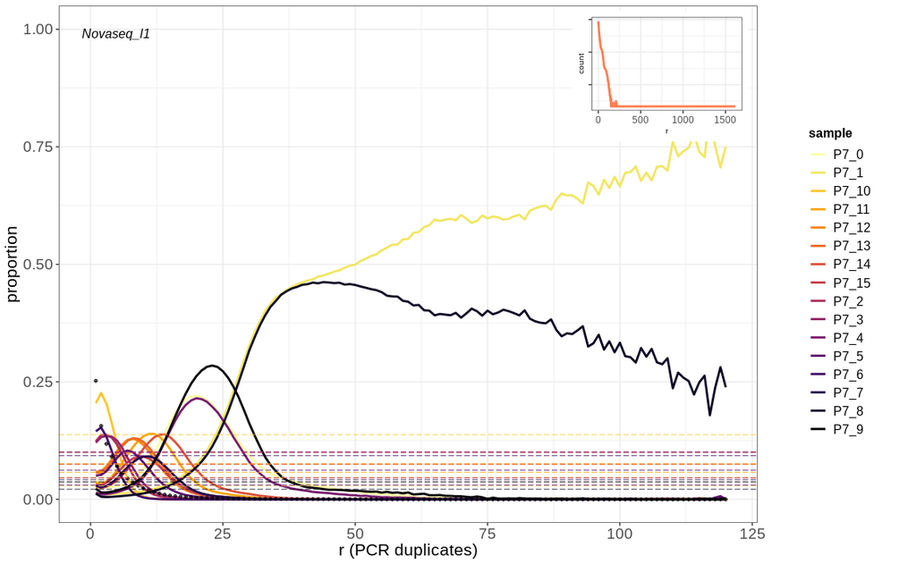

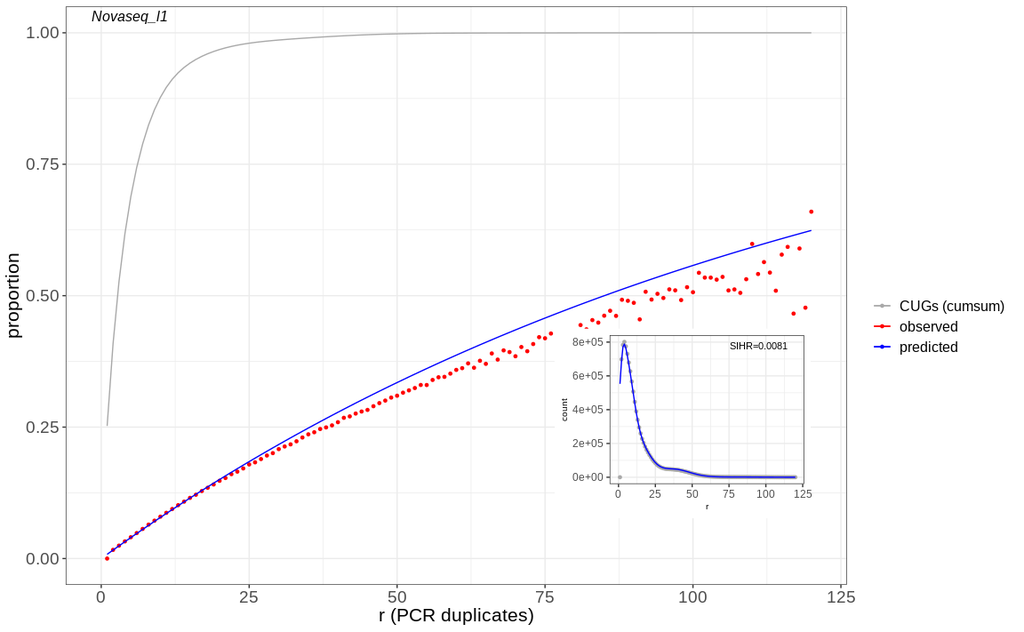

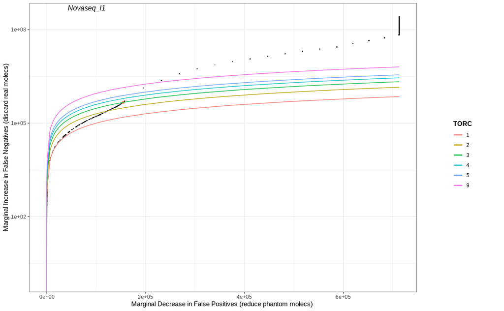

```r
plots
```